# Lesson 4 R Activity

Rick Davila

4/28/2020

## Lesson 4 - Install packages

```r
knitr::opts_chunk$set(echo = TRUE)

library(e1071)
library(xtable)
library("xlsx") # Needed to read data
```

```r
library(car) # Needed for alternative scatterplot matrix to default
library(scatterplot3d) # Needed for 3D scatterplot
library(matlib) # Needed for Invers() function
library(MASS) # Needed for ginv() function
library(standardize) # Needed for unit normal scaling in Example 3.14
rm(list = ls())
```

## Lesson 4 - Read data file (data-ex-3-1.xlsx)

```r
ex3_1 <- read.xlsx("data-ex-3-1.xlsx",
                   sheetIndex = 1,
                   colIndex = c(2,3,4),
                   as.data.frame = TRUE,
                   header = TRUE)
```

## Lesson 4 - Assign labels to data columns using names() and attach() commands

```r
names(ex3_1) <- c("Delivery_Time", "Num_Cases", "Distance")
attach(ex3_1)
```

## Lesson 4 - Output data to make sure it reads properly

```r
# Output data to make sure it reads properly
xtable(ex3_1)
```

| Delivery_Time | Num_Cases | Distance |
| --- | --- | --- |
| 16.68 | 7 | 560 |
| 11.50 | 3 | 220 |
| 12.03 | 3 | 340 |
| 14.88 | 4 | 80 |
| 13.75 | 6 | 150 |
| 18.11 | 7 | 330 |
| 8.00 | 2 | 110 |
| 17.83 | 7 | 210 |
| 79.24 | 30 | 1460 |
| 21.50 | 5 | 605 |

[output cut: 15 more lines]

## Lesson 4 - Output data structure and dimensions

```r
# output dataframe structure
str(ex3_1)
```

```
## 'data.frame':    25 obs. of  3 variables:
##  $ Delivery_Time: num  16.7 11.5 12 14.9 13.8 ...
##  $ Num_Cases    : num  7 3 3 4 6 7 2 7 30 5 ...
##  $ Distance     : num  560 220 340 80 150 330 110 210 1460 605 ...
```

```r
# dim of data 'matrix'
dim(ex3_1)
```

```
## [1] 25  3
```

## Lesson 4 - Example 3.1 (p. 75-77)

#### Ex 3.1. Create pairwise scatterplots using pairs() command

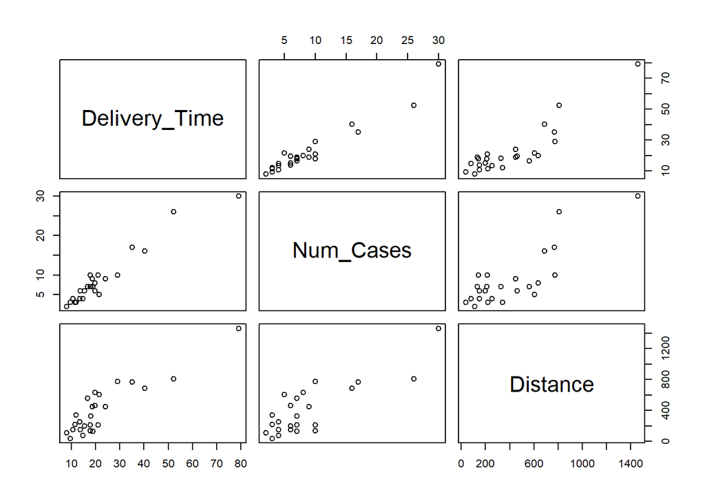

```r
# pairs() - The pairs function returns a plot matrix, consisting of scatterplots for each variable-combination of a data frame.

pairs(ex3_1)
```

#### Ex 3.1. Create pairwise scatterplots using the scatterplotMatrix() command from the “car” package

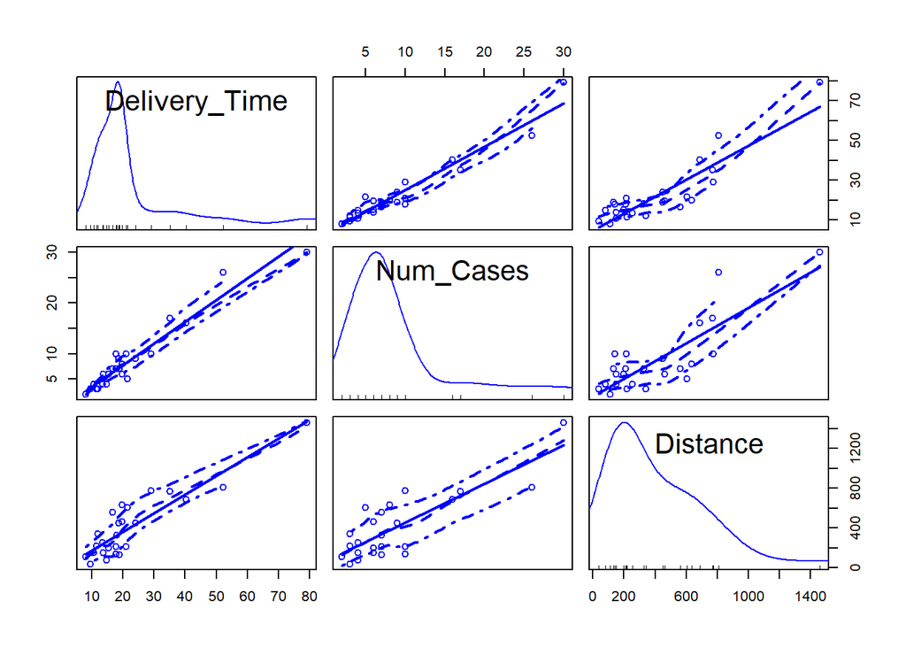

```r
# The scatterplotMatrix function provides a convenient interface to the pairs function to produce enhanced scatterplot matrices, including univariate displays on the diagonal and a variety of fitted lines, smoothers, variance functions, and concentration ellipsoids.

scatterplotMatrix(ex3_1, use = c("pairwise.complete.obs"))
```

#### Ex 3.1. Create 3D scatterplot using scatterplot3d() command from “scatterplot3d” package

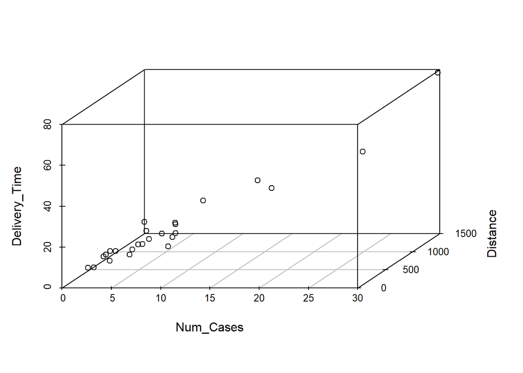

```r
# Plots a three dimensional (3D) point cloud
scatterplot3d(Num_Cases, Distance, Delivery_Time)
```

#### Ex 3.1. Obtain regression estimators using matrix algebra (“by hand”) #### Define X matrix of regressor observations (don’t forget to include column for intercept)

```r
X <- cbind(matrix(1,length(Distance),1),as.matrix(Num_Cases),as.matrix(Distance))
y <- as.matrix(Delivery_Time)
```

#### Ex 3.1. Display X to make sure it is correct; compare to p. 75)

```r
# display X matrix
X
```

```
##       [,1] [,2] [,3]
##  [1,]    1    7  560
##  [2,]    1    3  220
##  [3,]    1    3  340
##  [4,]    1    4   80
##  [5,]    1    6  150
##  [6,]    1    7  330
##  [7,]    1    2  110
##  [8,]    1    7  210
##  [9,]    1   30 1460
## [10,]    1    5  605
## [11,]    1   16  688
## [12,]    1   10  215
## [13,]    1    4  255
## [14,]    1    6  462
## [15,]    1    9  448
## [16,]    1   10  776
## [17,]    1    6  200
## [18,]    1    7  132
## [19,]    1    3   36
## [20,]    1   17  770
## [21,]    1   10  140
## [22,]    1   26  810
## [23,]    1    9  450
## [24,]    1    8  635
## [25,]    1    4  150
```

#### Ex 3.1. Define the matrix product of X_Transpose and X and display output to make sure it is correct (compare to p. 76)

```r
# X'X matrix
xTx <- t(X) %*% X
xTx
```

```
##       [,1]   [,2]    [,3]
## [1,]    25    219   10232
## [2,]   219   3055  133899
## [3,] 10232 133899 6725688
```

#### Ex 3.1. Take the inverse of xTx (“x-Transpose time x”) using three different approaches: Inverse(), ginv(), and inv() and display output to make sure it is correct (compare to p. 77)

```r
print("Inverse(xTx)")
```

```
## [1] "Inverse(xTx)"
```

```r
Inverse(xTx)
```

```
##             [,1]        [,2]       [,3]
## [1,]  0.11321519 -0.00444859 -8.367e-05
## [2,] -0.00444859  0.00274378 -4.786e-05
## [3,] -0.00008367 -0.00004786  1.230e-06
```

```r
print("ginv(xTx)")
```

```
## [1] "ginv(xTx)"
```

```r
ginv(xTx)
```

```
##               [,1]          [,2]          [,3]
## [1,]  1.132152e-01 -4.448593e-03 -8.367257e-05
## [2,] -4.448593e-03  2.743783e-03 -4.785709e-05
## [3,] -8.367257e-05 -4.785709e-05  1.228745e-06
```

```r
print("inv(xTx)")
```

```
## [1] "inv(xTx)"
```

```r
inv(xTx)
```

```
##             [,1]        [,2]       [,3]
## [1,]  0.11321519 -0.00444859 -8.367e-05
## [2,] -0.00444859  0.00274378 -4.786e-05
## [3,] -0.00008367 -0.00004786  1.230e-06
```

#### Ex 3.1. Illustration - the above matrix inverse calculations are possibly bad. How to tell? Take the inverse of the inverse using each approach and see…

```r
print("Inverse(Inverse(xTx))")
```

```
## [1] "Inverse(Inverse(xTx))"
```

```r
Inverse(Inverse(xTx))
```

```
##             [,1]        [,2]       [,3]
## [1,]    24.88136    217.4561   10153.88
## [2,]   217.45605   3034.9085  132882.33
## [3,] 10153.87809 132882.3328 6674246.69
```

```r
print("ginv(ginv(xTx))")
```

```
## [1] "ginv(ginv(xTx))"
```

```r
ginv(ginv(xTx))
```

```
##       [,1]   [,2]    [,3]
## [1,]    25    219   10232
## [2,]   219   3055  133899
## [3,] 10232 133899 6725688
```

```r
print("inv(inv(xTx))")
```

```
## [1] "inv(inv(xTx))"
```

```r
inv(inv(xTx))
```

```
##             [,1]        [,2]       [,3]
## [1,]    24.88136    217.4561   10153.88
## [2,]   217.45605   3034.9085  132882.33
## [3,] 10153.87809 132882.3328 6674246.69
```

ginv(ginv(xTx)) returns the original matrix

#### Ex 3.1. Continuing on… use ginv() for matrix inverse calculations from here on out. Define / calculate X-transpose * y, where y is the vector of dependent variable observations. Compare to p. 77

```r
print("X-transpose * y")
```

```
## [1] "X-transpose * y"
```

```r
t(X) %*% y
```

```
##           [,1]
## [1,]    559.60
## [2,]   7375.44
## [3,] 337071.69
```

#### Ex 3.1. Calculate Beta coefficients. Compare to values on p. 77.

```r
# The least-squares estimator of beta_coeffs

print("Beta Coefficients")
```

```
## [1] "Beta Coefficients"
```

```r
beta_hat <- ginv(xTx) %*% t(X) %*% y
beta_hat
```

```
##            [,1]
## [1,] 2.34123115
## [2,] 1.61590721
## [3,] 0.01438483
```

So we have ˆy = 2.3412311 + 1.6159072x1 + 0.0143848x2

The equation is
$$\hat{y} = (2.3412311) + (1.6159072)x_1 + (0.0143848)x_2$$
#### Ex 3.1. Obtain regression estimates using lm command

```r
model <- lm(Delivery_Time ~ Num_Cases + Distance)
xtable(model)
```

|  | Estimate | Std. Error | t value | Pr(>\|t\|) |
| --- | --- | --- | --- | --- |
| (Intercept) | 2.34123115 | 1.096730168 | 2.134738 | 4.417012e-02 |
| Num_Cases | 1.61590721 | 0.170734918 | 9.464421 | 3.254932e-09 |
| Distance | 0.01438483 | 0.003613086 | 3.981313 | 6.312469e-04 |

```r
# aov table
xtable(summary(aov(model)))
```

|  | Df | Sum Sq | Mean Sq | F value | Pr(>F) |
| --- | --- | --- | --- | --- | --- |
| Num_Cases | 1 | 5382.4088 | 5382.40880 | 506.61936 | 1.112549e-16 |
| Distance | 1 | 168.4021 | 168.40213 | 15.85085 | 6.312469e-04 |
| Residuals | 22 | 233.7317 | 10.62417 | NA | NA |

```r
# R coefficient
res <- data.frame(model$residuals)
colnames(res) <- "Residuals"
out <- as.data.frame(c(sigma(model), summary(model)$r.squared, summary(model)$adj.r.squared))
names(out) <- ""
rownames(out) <- c("$$S$$", "$$R^2$$", "$$R^{2}_{adj}$$")
xtable(out, digits=6)
```

| $$S$$ | 3.2594734 |
| --- | --- |
| $$R^2$$ | 0.9595937 |
| $$R^{2}_{adj}$$ | 0.9559205 |

```r
#xtable(res)
```

## Lesson 4 - Example 3.2 (p. 81)

#### Calculate SS_Residual (by hand) using the definition of a residual on p.80

$$SS_{res} = \sum\limits_{i=1}^n \left(y_i - \hat{y_i}\right)^2$$

```r
y_hat <- beta_hat[1,1] + beta_hat[2,1]*Num_Cases + beta_hat[3,1]*Distance
SS_res1 <- sum((Delivery_Time - y_hat)^2)
SS_res1
```

```
## [1] 233.7317
```

$$SS_{res} = \sum\limits_{i=1}^n \left(y_i - \hat{y_i}\right)^2 = 233.7316774$$
#### Ex 3.2. Calculate SS_Residual using matrix algebra formula on p. 81.

```r
yprime_y <- t(Delivery_Time) %*% Delivery_Time
beta_x_y <- t(beta_hat)%*%t(X)%*% Delivery_Time
SS_res2 <- yprime_y - beta_x_y
SS_res2
```

```
##          [,1]
## [1,] 233.7317
```

The residual sum of squares using using the matrix algebra formula is:
$$SS_{res} = \mathbf{y^{\prime}y - \hat{\beta^{\prime}}X^{\prime}y} = 233.7316774$$
#### Ex 3.2. Learning point: Different packages use different ‘behind the curtain’ approaches to calculate the matrix inverse. For some reason, inv() and Inverse() use rounding that results in over half of the SS_Residual being lost. Using ginv(), from the MASS package, gives results that match the textbook and the results obtained from the lm() command

```r
# The least-squares estimator of beta_coeffs using inv() and Inverse()

print("Beta Coefficients - using inv()")
```

```
## [1] "Beta Coefficients - using inv()"
```

```r
beta_hat_inv <- inv(xTx) %*% t(X) %*% y

# yprime_y calculated in Ex 3.1
beta_x_y_inv <- t(beta_hat_inv)%*%t(X)%*% Delivery_Time
SS_res_inv <- yprime_y - beta_x_y_inv

print("Beta Coefficients - using Inverse()")
```

```
## [1] "Beta Coefficients - using Inverse()"
```

```r
beta_hat_Inverse = Inverse(xTx) %*% t(X) %*% y

beta_x_y_Inverse <- t(beta_hat_Inverse)%*%t(X)%*% Delivery_Time
SS_res_Inverse <- yprime_y - beta_x_y_Inverse
```

The residual sum of squares using using the matrix algebra formula and inv() function is:
$$SS_{res} = \mathbf{y^{\prime}y - \hat{\beta^{\prime}}X^{\prime}y} = 104.7801627$$
The residual sum of squares using using the matrix algebra formula and Inverse() function is:
$$SS_{res} = \mathbf{y^{\prime}y - \hat{\beta^{\prime}}X^{\prime}y} = 104.7801627$$
#### Ex 3.2. Note also the discrepancy between using the definition of a residual and using the matrix algebra in Equation 3.16

```r
# Using the inv() function
y_hat <- beta_hat_inv[1,1] + beta_hat_inv[2,1]*Num_Cases + beta_hat_inv[3,1]*Distance
SS_res_inv2 <- sum((Delivery_Time - y_hat)^2)

# Using the inv() function
y_hat <- beta_hat_Inverse[1,1] + beta_hat_Inverse[2,1]*Num_Cases + beta_hat_Inverse[3,1]*Distance
SS_res_Inverse2 <- sum((Delivery_Time - y_hat)^2)
```

The residual sum of squares resulting from using inv()
$$SS_{res} = \sum\limits_{i=1}^n \left(y_i - \hat{y_i}\right)^2 = 234.725971$$
The residual sum of squares resulting from using Inverse()
$$SS_{res} = \sum\limits_{i=1}^n \left(y_i - \hat{y_i}\right)^2 = 234.725971$$
#### Ex 3.2. Calculate SST and SS_Regression (by hand). Compare to ANOVA table on p. 78. Values match.

```r
SS_T <- t(Delivery_Time)%*%Delivery_Time-(sum(Delivery_Time))^2/length(Delivery_Time)
SS_R <- t(beta_hat)%*%t(X)%*%Delivery_Time-(sum(Delivery_Time))^2/length(Delivery_Time)
```

$$SS_{T} = \mathbf{y^{\prime}y}-\frac{\left(\sum\limits_{i=1}^n y_i\right)^2}{n} = 5784.5426$$
$$SS_{R} = \mathbf{\hat{\beta}^{\prime}X^{\prime}y}-\frac{\left(\sum\limits_{i=1}^n y_i\right)^2}{n} = 5550.8109226$$
The $SS_T$ and $SS_R$ calculated values are consistent with the values reported in the book’s ANOVA table ($5784.5$ for $SS_T$ and $5550.8$ for $SS_R$).

#### Ex 3.2. Calculate ANOVA table using anova() and display the output

```r
# anova table, model calculated using lm() in Ex 3.1 abov
anova(model)
```

|  | Df | Sum Sq | Mean Sq | F value | Pr(>F) |
| --- | --- | --- | --- | --- | --- |
| Num_Cases | 1 | 5382.4088 | 5382.40880 | 506.61936 | 1.112549e-16 |
| Distance | 1 | 168.4021 | 168.40213 | 15.85085 | 6.312469e-04 |
| Residuals | 22 | 233.7317 | 10.62417 | NA | NA |

```r
summary(anova(model))
```

```
##        Df           Sum Sq          Mean Sq           F value
##  Min.   : 1.0   Min.   : 168.4   Min.   :  10.62   Min.   : 15.85
##  1st Qu.: 1.0   1st Qu.: 201.1   1st Qu.:  89.51   1st Qu.:138.54
##  Median : 1.0   Median : 233.7   Median : 168.40   Median :261.24
##  Mean   : 8.0   Mean   :1928.2   Mean   :1853.81   Mean   :261.24
##  3rd Qu.:11.5   3rd Qu.:2808.1   3rd Qu.:2775.41   3rd Qu.:383.93
##  Max.   :22.0   Max.   :5382.4   Max.   :5382.41   Max.   :506.62
##                                                    NA's   :1
##      Pr(>F)
##  Min.   :0.0000000
##  1st Qu.:0.0001578
##  Median :0.0003156
##  Mean   :0.0003156
##  3rd Qu.:0.0004734
##  Max.   :0.0006312
##  NA's   :1
```

## Lesson 4 - Example 3.3 (p. 87)

#### Test for significance of regression using F-test (by hand)

#### Calculate degrees of freedom. Output to make sure it is correct; compare to the ANOVA table on p. 87. The test for significance is a test to determine if there is a linear relationship between the response and any of the regressor variables.

```r
# degrees of freedom
k <- 2                     # number of beta regressor parameters
n <- length(Delivery_Time) # number of obervations

SS_reg_df <- k
SS_res_df <- n-k-1
SS_T_df <- n - 1
```

$$SS_{R}df = 2$$
$$SS_{res}df = 22$$
$$SS_{T}df = 24$$
#### Ex 3.3. Calculate Mean-Square for Regression and Residual

```r
# n = length(Delivery_Time); calculated in previous chunk

SS_T <- t(Delivery_Time)%*%Delivery_Time - (sum(Delivery_Time))^2/n
SS_R <- t(beta_hat) %*% t(X) %*% Delivery_Time - (sum(Delivery_Time))^2/n
SS_res <- SS_T - SS_R
```

$$SS_{R} = 5550.8109226$$
$$SS_{res} = 233.7316774$$
#### Ex 3.3. Calculate F-test algebraically and F-critical using qf() command

```r
# recall, k = 2 (above)

MS_R <- SS_R/k
MS_res <- SS_res/(n-k-1)
F_0 <- MS_R/MS_res

# F critical using the qf() command at the 0.01 significance
siglevel <- 0.01

Fcritical <- qf(1-siglevel, SS_reg_df, SS_res_df)
```

The $F_0$ statistic is
$$F_0 = \frac{MS_R}{MS_{res}}=\frac{2775.4054613}{10.6241672}=261.2351087$$

The $F$ critical value is
$$F_0 = 5.7190219$$

## Lesson 4 - Example 3.4 (p. 88-89)

#### Test the significance of the individual regression coefficients (by hand)

#### Define C matrix for use in computing se(B_j)

```r
# xTx matrix calculated in the begining of this lesson R activity
C_matrix <- ginv(xTx)
C_matrix
```

```
##               [,1]          [,2]          [,3]
## [1,]  1.132152e-01 -4.448593e-03 -8.367257e-05
## [2,] -4.448593e-03  2.743783e-03 -4.785709e-05
## [3,] -8.367257e-05 -4.785709e-05  1.228745e-06
```

#### Ex 3.4. (p. 88-89) Compute the t-test algebraically and t-critical using qt() command. Calculate p-value using pt() command.

```r
# n is the number of observations and p is the number of beta parameters
p <- length(beta_hat)
sigma_hat_sq = SS_res/(n - p)

# calculate t statistic for regressor parameters beta_1 and beta_2
t0_beta2 = beta_hat[2,1]/sqrt(sigma_hat_sq * C_matrix[2,2])
t0_beta3 = beta_hat[3,1]/sqrt(sigma_hat_sq * C_matrix[3,3])

# t-critical and p-value calculations
# for alpha = 0.05
alpha = 0.05

tcritical_value = abs(qt(alpha/2, df = SS_res_df))
p_value_beta2 = 2*pt(-abs(t0_beta2), df = SS_res_df)
p_value_beta3 = 2*pt(-abs(t0_beta3), df = SS_res_df)
```

## Lesson 4 - Example 3.5 (p. 92-93)

#### Perform partial F-test on the significance of the contribution of Distance to the full model

#### Ex 3.5. Create full model using lm() command

```r
y_bar = sum(Delivery_Time)/length(Delivery_Time)
model_full <- lm(Delivery_Time ~ Num_Cases + Distance)

beta_0 <- model_full$coefficients[1]
beta_1 <- model_full$coefficients[2]
beta_2 <- model_full$coefficients[3]

y_hat <- beta_0 + beta_1*Num_Cases + beta_2*Distance
SS_R_mf <- sum((y_hat - y_bar)^2)
```

#### Ex 3.5. Create reduced model using lm() command

```r
# excludes the Distance parameter

model_reduced <- lm(Delivery_Time ~ Num_Cases)
beta_0 <- model_reduced$coefficients[1]
beta_1 <- model_reduced$coefficients[2]

y_hat <- beta_0 + beta_1*Num_Cases
SS_R_mr <- sum((y_hat - y_bar)^2)
```

#### Ex 3.5. Create F-test algebraically and F-critical using qf() command

```r
r <- length(model_full$coefficients) - length(model_reduced$coefficients)
p <- length(model_full$coefficients)
n <- length(Delivery_Time)

SS_R_beta2contrib = SS_R_mf - SS_R_mr

F_0 <- (SS_R_beta2contrib/r)/MS_res

alpha = 0.05
F_critical <- qf(1-alpha,r,n-p)
```

$$F_0=\frac{\beta_2|\beta_1,\beta_0/1}{MS_{Res}}=\frac{168.4021256}{10.6241672}=15.8508543$$
Since $F_{0.05,1,22} = 4.3009495$, we conclude that Distance (x2) contributes significantly to the model.

#### Ex 3.5. Faster way with R - Use anova() command

```r
# use anova() function on the ful model
F_0anova <- anova(model_full)$F[2]
```